# 03 · Feature Engineering

A partir del dataset integrado (`dataset_integrado_horario.parquet`) se construyen las variables de entrada para el modelo de predicción espacio-temporal. La **variable objetivo** es `sm` (segundos por metro), la velocidad invertida normalizada por la longitud del tramo, que permite comparar directamente corredores de distintas dimensiones.

## Bloques de features

| Bloque | Variables generadas |
| --- | --- |
| **1 · Lag features** | Valores pasados de `sm` por tram (1h–168h) + lags de tiempo de viaje |
| **2 · Rolling windows** | Medias, desv. estándar y máximos deslizantes de `sm` por tram |
| **3 · Features derivadas** | Delta tiempo, tendencia acumulada, rush-hour flags |
| **4 · Interacciones evento × hora** | Productos cruzados entre `hay_evento` (flag unificado FCB + conciertos + ferias + festivales) y contexto temporal |
| **5 · Validación** | Diagnóstico de nulos, distribuciones, correlaciones con `sm` |

**Output:** `dataset/integrated/dataset_features.parquet`

```python
import warnings
from pathlib import Path

import numpy as np
import pandas as pd
import matplotlib.pyplot as plt
import matplotlib.ticker as mticker
import seaborn as sns

warnings.filterwarnings('ignore')
pd.set_option('display.max_columns', 60)
pd.set_option('display.float_format', '{:.4f}'.format)
sns.set_theme(style='whitegrid', palette='muted', font_scale=1.1)
plt.rcParams['figure.figsize'] = (14, 4)

DATA_DIR = Path('../dataset')
IN_PATH  = DATA_DIR / 'integrated' / 'dataset_integrado_horario.parquet'
OUT_PATH = DATA_DIR / 'integrated' / 'dataset_features.parquet'

TARGET = 'sm'   # velocidad invertida normalizada (s/m); objetivo principal del modelo

print('Input: ', IN_PATH)
print('Output:', OUT_PATH)
print('Target:', TARGET)
```

```
Input:  ..\dataset\integrated\dataset_integrado_horario.parquet
Output: ..\dataset\integrated\dataset_features.parquet
Target: sm
```

## 0 · Carga y revisión inicial

```python
df = pd.read_parquet(IN_PATH)

# Ordenar por tram y hora — imprescindible para lag/rolling correctos
df = df.sort_values(['idTram', 'hora']).reset_index(drop=True)

# Columnas que llegan como object desde el parquet — convertir a float antes de operar
_obj_cols = ['factor_medio', 'factor_max', 'factor_min',
             'tiempo_actual', 'tiempo_previsto', 'tendencia_media']
for _col in _obj_cols:
    if _col in df.columns:
        df[_col] = pd.to_numeric(df[_col], errors='coerce')

target = TARGET

print(f'Shape: {df.shape}')
print(f'Periodo: {df.hora.min()} → {df.hora.max()}')
print(f'Trams únicos: {df.idTram.nunique():,}')
print(f'Horas únicas: {df.hora.nunique():,}')
print(f'Target ({target}): min={df[target].min():.4f}  max={df[target].max():.4f}  median={df[target].median():.4f}')
print()
print('Columnas de entrada:')
print(list(df.columns))
```

```
Shape: (741182, 55)
Periodo: 2021-07-01 00:00:00 → 2022-12-31 23:00:00
Trams únicos: 58
Horas únicas: 12,779
Target (sm): min=0.0093  max=2.8284  median=0.3023

Columnas de entrada:
['idTram', 'hora', 'factor_medio', 'factor_max', 'factor_min', 'factor_std', 'tiempo_actual', 'tiempo_previsto', 'tendencia_media', 'n_mediciones', 'sensor_trafico_ok', 'anyo', 'mes', 'dia_mes', 'hora_dia', 'dia_semana', 'es_fin_semana', 'semana_anyo', 'hora_sin', 'hora_cos', 'mes_sin', 'mes_cos', '…
```

> **Dataset cargado:** 741.182 filas × 55 columnas · periodo 2021-07-01 → 2022-12-31. El dataset incluye las columnas AEMET horarias (`temp_media_c`, `humedad_rel_pct`, `presion_hpa`, `precipitacion_mm`, `viento_vel_ms`, `viento_dir_grad`, `nubosidad_oktas`, `visibilidad_km`, `lluvia`), el flag unificado `hay_evento` y la variable objetivo `sm`.

> **Rango de `sm`:** 0.0093 – 2.8284 s/m · mediana 0.3023 s/m ≈ **11,9 km/h**. El mínimo global (0.009 s/m ≈ 400 km/h equivalente) corresponde a horas con registros prácticamente libres de tráfico; el máximo (2.83 s/m ≈ 1.3 km/h) a episodios de atasco severo.

> Las columnas `factor_medio`, `factor_max`, `factor_min`, `tiempo_actual`, `tiempo_previsto` y `tendencia_media` se convierten de `object` a `float64` mediante `pd.to_numeric(..., errors='coerce')` antes de cualquier operación aritmética.

```python
# Snapshot de nulos de partida
nulos_base = (df.isnull().mean() * 100).round(2)
print('Columnas con nulos (%):')
print(nulos_base[nulos_base > 0].sort_values(ascending=False).to_string())
```

```
Columnas con nulos (%):
idItinerari        58.6200
factor_std         15.3800
factor_medio       15.0500
factor_min         15.0500
factor_max         15.0500
tendencia_media    15.0500
sm                 15.0400
presion_hpa         1.4200
visibilidad_km      1.3100
precipitacion_mm    0.0300
nubosidad_oktas     0.0300
viento_dir_grad     0.0200
viento_vel_ms       0.0200
```

> Fotografía inicial de nulos en el dataset de entrada. Se distinguen tres grupos:

| Grupo | Columnas afectadas | Nulos |
| --- | --- | --- |
| Sin itinerario asignado | `idItinerari` | 58,6 % |
| Horas sin medición válida | `factor_std`, `tendencia_media`, `factor_max/min/medio`, `sm` | 15,0–15,4 % |
| AEMET sinóptico residual | `presion_hpa`, `nubosidad_oktas`, `visibilidad_km` | < 2 % |
| AEMET puntual | `precipitacion_mm`, `viento_vel_ms`, `viento_dir_grad` | < 0,1 % |

> Las tres variables sinópticas de AEMET (`presion_hpa`, `nubosidad_oktas`, `visibilidad_km`) ya están interpoladas en el cuaderno 02 mediante forward-fill por estación (límite 7–13 h) y son **directamente utilizables** como features.

## 1 · Lag features

Para cada tram, se desplazan hacia adelante los valores históricos de **`sm`** (velocidad invertida normalizada) y el **tiempo de viaje actual**. Los lags capturan la autocorrelación temporal: el `sm` de hace 1 hora o hace 7 días es un predictor fuerte del `sm` actual.

| Lag | Razonamiento |
| --- | --- |
| 1 h, 2 h, 3 h | Inercia a corto plazo |
| 6 h, 12 h | Patrón de media jornada |
| 24 h | Mismo momento del día anterior |
| 48 h | Anteayer |
| 168 h | Misma hora de la semana pasada |

> **Nota:** se agrupan por `idTram` para no mezclar lags entre trams distintos.

```python
LAGS_SM     = [1, 2, 3, 6, 12, 24, 48, 168]
LAGS_TIEMPO = [24, 168]

grp = df.groupby('idTram', sort=False)

# Lag de sm (velocidad invertida normalizada por longitud de tramo)
for lag in LAGS_SM:
    df[f'sm_lag_{lag}h'] = grp['sm'].shift(lag)

# Lag del tiempo de viaje actual
for lag in LAGS_TIEMPO:
    df[f'tiempo_lag_{lag}h'] = grp['tiempo_actual'].shift(lag)

# Diferencias de primer orden (velocidad de cambio del sm)
df['sm_diff_1h']  = df['sm'] - df['sm_lag_1h']
df['sm_diff_24h'] = df['sm'] - df['sm_lag_24h']

lag_cols = [c for c in df.columns if 'lag' in c or 'diff' in c]
print(f'Columnas lag generadas: {len(lag_cols)}')
print(lag_cols)

nulos_lag = df[lag_cols].isnull().mean().mul(100).round(1)
print('\nNulos (%) por columna lag:')
print(nulos_lag.to_string())
```

```
Columnas lag generadas: 12
['sm_lag_1h', 'sm_lag_2h', 'sm_lag_3h', 'sm_lag_6h', 'sm_lag_12h', 'sm_lag_24h', 'sm_lag_48h', 'sm_lag_168h', 'tiempo_lag_24h', 'tiempo_lag_168h', 'sm_diff_1h', 'sm_diff_24h']

Nulos (%) por columna lag:
sm_lag_1h         15.0000
sm_lag_2h         15.1000
sm_lag_3h         15.1000
sm_lag_6h         15.1000
sm_lag_12h        15.1000
sm_lag_24h        15.2000
sm_lag_48h        15.4000
sm_lag_168h       16.1000
tiempo_lag_24h     0.2000
tiempo_lag_168h    1.3000
sm_diff_1h        15.3000
sm_diff_24h       16.1000
```

> **12 columnas de lag generadas:**
> - `sm_lag_1h` a `sm_lag_168h` (8 lags): valor de `sm` del mismo tram en instantes pasados.
> - `tiempo_lag_24h`, `tiempo_lag_168h`: tiempo de viaje del día anterior y de la semana pasada.
> - `sm_diff_1h`, `sm_diff_24h`: velocidad de cambio del `sm` (Δ en s/m).

> **Nulos observados:** todos los lags de `sm` presentan ~15 % de nulos, heredados directamente del 15,04 % de nulos de la columna fuente (`sm`). Esto revela que la causa dominante no es el período de arranque de la serie (que solo afectaría a las primeras N horas), sino los huecos estructurales en los sensores de origen. El lag 168h acumula un punto extra (16,1 %) por sumar también el período de arranque de 7 días. En contraste, `tiempo_lag_24h` (0,2 %) y `tiempo_lag_168h` (1,3 %) confirman que `tiempo_actual` tiene cobertura mucho más completa que `sm`.

## 2 · Rolling windows

Las ventanas deslizantes suavizan el ruido puntual y exponen tendencias de `sm` a distintas escalas temporales. Se usa `min_periods=1` para no perder filas cuando el tram tiene menos datos que el tamaño de la ventana.

| Ventana | Estadísticos calculados |
| --- | --- |
| 3 h | media |
| 6 h | media, desv. estándar |
| 12 h | media |
| 24 h | media, desv. estándar, máximo |
| 168 h | media (patrón semanal) |

```python
def rolling_by_tram(series: pd.Series, window: int, func: str, min_p: int = 1) -> pd.Series:
    'Rolling statistic agrupado por idTram, basado en un offset de posiciones.'
    return (
        series
        .groupby(df['idTram'], sort=False)
        .transform(lambda x: getattr(x.shift(1).rolling(window, min_periods=min_p), func)())
    )

# Media deslizante de sm
for w in [3, 6, 12, 24, 168]:
    df[f'sm_rmean_{w}h'] = rolling_by_tram(df['sm'], w, 'mean')

# Desviación estándar (volatilidad de sm)
for w in [6, 24]:
    df[f'sm_rstd_{w}h'] = rolling_by_tram(df['sm'], w, 'std', min_p=2)

# Máximo deslizante de sm (pico reciente de congestión)
df['sm_rmax_24h'] = rolling_by_tram(df['sm'], 24, 'max')

# Diferencia media-corto vs media-largo (momentum de sm)
df['sm_momentum'] = df['sm_rmean_3h'] - df['sm_rmean_24h']

roll_cols = [c for c in df.columns if 'rmean' in c or 'rstd' in c or 'rmax' in c or 'momentum' in c]
print(f'Columnas rolling generadas: {len(roll_cols)}')
print(roll_cols)

nulos_roll = df[roll_cols].isnull().mean().mul(100).round(1)
print('\nNulos (%) por columna rolling:')
print(nulos_roll.to_string())
```

```
Columnas rolling generadas: 9
['sm_rmean_3h', 'sm_rmean_6h', 'sm_rmean_12h', 'sm_rmean_24h', 'sm_rmean_168h', 'sm_rstd_6h', 'sm_rstd_24h', 'sm_rmax_24h', 'sm_momentum']

Nulos (%) por columna rolling:
sm_rmean_3h     14.6000
sm_rmean_6h     14.4000
sm_rmean_12h    14.1000
sm_rmean_24h    13.7000
sm_rmean_168h   12.2000
sm_rstd_6h      14.6000
sm_rstd_24h     14.0000
sm_rmax_24h     13.7000
sm_momentum     14.6000
```

> **9 columnas de ventana deslizante generadas.** La función `rolling_by_tram` aplica `.shift(1)` antes del rolling para excluir el valor actual de la ventana (evita data leakage):
> - `sm_rmean_3h/6h/12h/24h/168h` — medias de `sm` sobre 3, 6, 12, 24 y 168 horas precedentes.
> - `sm_rstd_6h/24h` — volatilidad de `sm` a corto y largo plazo.
> - `sm_rmax_24h` — pico máximo de `sm` en las últimas 24 h.
> - `sm_momentum` — diferencia `sm_rmean_3h` − `sm_rmean_24h`: positivo indica aceleración de la congestión, negativo indica alivio.

> **Nulos observados:** 12,2 %–14,6 %. Notablemente *menores* que los lags (15–16 %) porque `min_periods=1` permite calcular la media con cualquier observación disponible dentro de la ventana, reduciendo los huecos. `sm_rmean_168h` tiene el menor porcentaje de nulos (12,2 %) porque la ventana semanal da más oportunidades de encontrar al menos un valor válido. `sm_rstd_6h` y `sm_momentum` tienen los mayores (14,6 %) porque `rstd` requiere mínimo 2 observaciones y `momentum` hereda los nulos de `sm_rmean_3h`.

## 3 · Features derivadas del tráfico

Variables calculadas a partir de columnas ya existentes que añaden semántica explícita al modelo. `tiempo_actual` y `tiempo_previsto` ya han sido convertidas a float en la carga inicial.

```python
# Delta tiempo: diferencia entre tiempo actual y previsto
# Positivo → tráfico peor de lo esperado; negativo → mejor
df['delta_tiempo'] = df['tiempo_actual'] - df['tiempo_previsto']

# Ratio tiempo actual / previsto (normaliza por longitud del tram)
df['ratio_tiempo'] = np.where(
    df['tiempo_previsto'] > 0,
    df['tiempo_actual'] / df['tiempo_previsto'],
    np.nan
)

# Rango del factor en la hora (factor_max - factor_min)
df['factor_rango_hora'] = df['factor_max'] - df['factor_min']

# Flags de hora punta
df['es_hora_punta_manyana'] = df['hora_dia'].between(7, 9).astype(int)
df['es_hora_punta_tarde']   = df['hora_dia'].between(17, 20).astype(int)
df['es_hora_punta']         = ((df['es_hora_punta_manyana'] == 1) | (df['es_hora_punta_tarde'] == 1)).astype(int)

# Flag noche (menor actividad)
df['es_noche'] = ((df['hora_dia'] >= 23) | (df['hora_dia'] <= 5)).astype(int)

# Interacción hora punta × día laborable
df['hora_punta_laborable'] = df['es_hora_punta'] * (1 - df['es_fin_semana'])

derived_cols = ['delta_tiempo', 'ratio_tiempo', 'factor_rango_hora',
                'es_hora_punta_manyana', 'es_hora_punta_tarde', 'es_hora_punta',
                'es_noche', 'hora_punta_laborable']
print('Features derivadas:', derived_cols)
df[derived_cols].describe().T[['mean', 'std', 'min', 'max']]
```

```
Features derivadas: ['delta_tiempo', 'ratio_tiempo', 'factor_rango_hora', 'es_hora_punta_manyana', 'es_hora_punta_tarde', 'es_hora_punta', 'es_noche', 'hora_punta_laborable']
```

|  | mean | std | min | max |
| --- | --- | --- | --- | --- |
| delta_tiempo | 1.9636 | 11.8028 | -466.0000 | 469.0000 |
| ratio_tiempo | 1.0138 | 0.0698 | 0.3365 | 4.0351 |
| factor_rango_hora | 0.0441 | 0.2311 | 0.0000 | 2.0000 |
| es_hora_punta_manyana | 0.1250 | 0.3308 | 0.0000 | 1.0000 |
| es_hora_punta_tarde | 0.1668 | 0.3728 | 0.0000 | 1.0000 |
| es_hora_punta | 0.2919 | 0.4546 | 0.0000 | 1.0000 |
| es_noche | 0.2907 | 0.4541 | 0.0000 | 1.0000 |
| hora_punta_laborable | 0.2088 | 0.4064 | 0.0000 | 1.0000 |

> **8 features semánticas derivadas:**
> - `delta_tiempo` — media 1,96 s (ligero retraso típico sobre el previsto), rango −466 s a +469 s. Los extremos corresponden a disrupciones graves o recuperaciones bruscas.
> - `ratio_tiempo` — media 1,014 (tráfico un 1,4 % peor que la referencia en promedio), rango 0,34–4,04. Un ratio > 1,2 señala congestión significativa.
> - `factor_rango_hora` — media 0,044, máximo 2,0. La mayoría de horas tienen variabilidad intra-horaria muy baja; solo los episodios de congestión/descongestión producen rangos altos.
> - `es_hora_punta_manyana` / `es_hora_punta_tarde` / `es_hora_punta` — representan el 12,5 %, 16,7 % y 29,2 % de las horas respectivamente.
> - `es_noche` — 29,1 % de las horas (23 h–5 h).
> - `hora_punta_laborable` — 20,9 % de las horas: el subconjunto de alta demanda con impacto real en la movilidad laboral.

## 3.5 · Features estáticas de tipología de vía

La tipología y longitud de cada corredor son rasgos **estáticos** (no cambian con el tiempo) que determinan la capacidad de absorber tráfico y la sensibilidad a eventos externos. Un `Carrer` estrecho y una `Diagonal` reaccionan de forma estructuralmente distinta ante un concierto en el Palau Sant Jordi.

| Feature | Tipo | Descripción |
| --- | --- | --- |
| `tipo_via_cod` | int8 (ordinal) | Tipología codificada como entero; LightGBM la trata como categórica |
| `longitud_tramo_m` | float32 | Longitud del corredor (metros, Haversine entre extremos) |

```python
# --- 3.5 Features estáticas de tipología de vía ---
# tipo_via y longitud_tramo_m ya están en df (provienen del parquet integrado).
# Se codifica tipo_via como entero ordinal para LightGBM.
# Orden aproximado por capacidad de absorción de tráfico (mayor → mayor capacidad).

ORDEN_TIPO_VIA = [
    'Diagonal', 'Gran Via', 'Ronda',
    'Avinguda', 'Passeig', 'Via',
    'Rambla', 'Travessera', 'Tunel', 'Carrer'
]
tipo_map = {t: i for i, t in enumerate(ORDEN_TIPO_VIA)}

df['tipo_via_cod'] = df['tipo_via'].map(tipo_map).fillna(len(ORDEN_TIPO_VIA)).astype('int8')

# longitud_tramo_m: convertir a float32 para consistencia
df['longitud_tramo_m'] = df['longitud_tramo_m'].astype('float32')

print('tipo_via_cod — distribución:')
print(df.drop_duplicates('idTram')[['tipo_via', 'tipo_via_cod', 'longitud_tramo_m']]
      .sort_values('tipo_via_cod').to_string(index=False))
print(f'\nNulos tipo_via_cod: {df["tipo_via_cod"].isna().sum()}')
print(f'Nulos longitud_tramo_m: {df["longitud_tramo_m"].isna().sum()}')
```

```
tipo_via_cod — distribución:
  tipo_via  tipo_via_cod  longitud_tramo_m
  Diagonal             0          923.7029
  Diagonal             0          910.5934
  Diagonal             0          930.5001
  Diagonal             0          936.9326
  Diagonal             0          431.4602
  Diagonal             0          426.1140
  Diagonal             0          453.6412
  Diagonal             0          614.0758
  Avinguda             3          706.9423
  Avinguda             3          692.6021
  Avinguda             3          645.0035
  Avinguda             3          667.6536
  Avinguda             3          700.3877
  Avinguda             3          940.6345
  Avinguda             3          939.2439
  Avinguda             3          303.9710
  Avinguda             3          790.3810
  Avinguda             3          787.4872
  Avinguda             3          878.2031
  Avinguda             3          882.8370
  Avinguda             3          532.3363
  Avinguda             3          451.4494
  Avinguda             3          643.2160
   Passeig             4          892.7762
   Passeig             4         1183.6366
       Via             5          574.1011
       Via             5          393.9589
       Via             5          545.9606
       Via             5          569.9271
       Via             5          279.3860
       Via             5          302.5595
Travessera             7          717.9647
    Carrer             9          527.3688
    Carrer             9          686.7120
    Carrer             9          688.4724
    Carrer             9          713.3133
    Carrer             9          718.8596
    Carrer             9          509.3511
```

[output cut: 8 more lines]

```
    Carrer             9         1230.9812
    Carrer             9          791.2021
    Carrer             9          778.6135
    Carrer             9          611.6171
    Carrer             9          389.9821
    Carrer             9          366.5228
    Carrer             9          358.9046
    Carrer             9          247.2920
    Carrer             9          255.3296
    Carrer             9          698.8436
    Carrer             9          335.0312
    Carrer             9          325.4602

Nulos tipo_via_cod: 0
Nulos longitud_tramo_m: 0
```

> **Distribución de tipos de vía en los 58 trams monitorizados** (sin nulos):

[output not shown]

## 4 · Interacciones evento × hora

El impacto de un evento sobre el tráfico **no es uniforme**: un evento afecta más a las 20 h que a las 7 h, y más en fin de semana que en miércoles. Estas interacciones permiten al modelo aprender estos patrones diferenciados.

Se generan productos cruzados entre:

- **`hay_evento`** — flag unificado FCB + conciertos (Palau Sant Jordi) + ferias (Fira) + festivales/fiestas
- Contexto temporal (hora cíclica, día de semana, rush-hour)

```python
# --- 4.1 Evento × contexto temporal (hay_evento: flag unificado FCB + conciertos + ferias + festivales) ---

# Evento × codificación cíclica de la hora
df['evento_x_hora_sin'] = df['hay_evento'] * df['hora_sin']
df['evento_x_hora_cos'] = df['hay_evento'] * df['hora_cos']

# Evento × hora punta
df['evento_x_hora_punta'] = df['hay_evento'] * df['es_hora_punta']

# Evento × fin de semana
df['evento_x_finde'] = df['hay_evento'] * df['es_fin_semana']

# Evento × día de semana (permite aprender diferencias por día)
for d in range(7):
    df[f'evento_x_diasem_{d}'] = df['hay_evento'] * (df['dia_semana'] == d).astype(int)

# --- 4.2 Agenda cultural × contexto temporal ---

# Log(1 + n_eventos) para reducir el impacto de outliers
df['log_n_eventos'] = np.log1p(df['n_eventos_agenda'])

df['eventos_x_hora_sin']   = df['log_n_eventos'] * df['hora_sin']
df['eventos_x_hora_cos']   = df['log_n_eventos'] * df['hora_cos']
df['eventos_x_hora_punta'] = df['log_n_eventos'] * df['es_hora_punta']
df['eventos_x_finde']      = df['log_n_eventos'] * df['es_fin_semana']

# --- 4.3 Asistentes (intensidad del festival) × hora ---

# Normalizar asistentes con log para escalar la magnitud
df['log_asistentes'] = np.log1p(df['asistentes_festival'])

df['asistentes_x_hora_punta'] = df['log_asistentes'] * df['es_hora_punta']
df['asistentes_x_hora_sin']   = df['log_asistentes'] * df['hora_sin']
df['asistentes_x_hora_cos']   = df['log_asistentes'] * df['hora_cos']

# --- 4.4 Eventos × mes (estacionalidad) ---
df['evento_x_mes_sin'] = df['hay_evento'] * df['mes_sin']
df['evento_x_mes_cos'] = df['hay_evento'] * df['mes_cos']

interac_cols = [c for c in df.columns if '_x_' in c or c.startswith('log_')]
print(f'Columnas de interacción generadas: {len(interac_cols)}')
print(interac_cols)
```

```
Columnas de interacción generadas: 22
['evento_x_hora_sin', 'evento_x_hora_cos', 'evento_x_hora_punta', 'evento_x_finde', 'evento_x_diasem_0', 'evento_x_diasem_1', 'evento_x_diasem_2', 'evento_x_diasem_3', 'evento_x_diasem_4', 'evento_x_diasem_5', 'evento_x_diasem_6', 'log_n_eventos', 'eventos_x_hora_sin', 'eventos_x_hora_cos', 'eventos…
```

### 4.3 Features de proximidad geoespacial evento-corredor

Hasta ahora los eventos se aplican como señal binaria/conteo **uniforme** para todos los corredores. Esta sección añade **5 features de distancia** que permiten al modelo diferenciar el impacto según la proximidad física de cada corredor al evento activo:

| Feature | Descripción |
| --- | --- |
| `dist_evento_min_km` | Distancia haversine (km) al evento activo más cercano ese día; 0 si no hay evento |
| `inv_dist_evento` | 1/(1+dist) — señal de proximidad [0..1]; 0 si no hay evento |
| `asistentes_pond` | Σ(asistentes_ev × inv_dist) para todos los eventos del día |
| `log_asistentes_pond` | log(1 + asistentes_pond) — versión estabilizada |
| `hay_evento_3km` | 1 si algún evento activo está a ≤3 km del corredor |

**Fuentes de coordenadas:** Conciertos (Palau Sant Jordi), Ferias (Fira Gran Via), Partidos FCB (Camp Nou). Festivales/festes excluidos por falta de geocodificación.

```python
# --- 4.3 Features de proximidad geoespacial evento-corredor ---

# ── Cargar eventos con coordenadas ───────────────────────────────────────────
conc = pd.read_csv(DATA_DIR / 'Conciertos/conciertos_barcelona.csv',
                   usecols=['fecha','lat','lon','espectadores'])
conc = conc.rename(columns={'espectadores':'asistentes'})
conc['fecha'] = pd.to_datetime(conc['fecha']).dt.date

ferias_raw = pd.read_csv(DATA_DIR / 'Ferias/ferias_barcelona_2021_2022.csv',
                         usecols=['data_inici','data_fi','lat','lon','visitants_dia'])
ferias_raw['data_inici'] = pd.to_datetime(ferias_raw['data_inici'])
ferias_raw['data_fi']    = pd.to_datetime(ferias_raw['data_fi'])
ferias_rows = []
for _, r in ferias_raw.dropna(subset=['lat','lon']).iterrows():
    for d in pd.date_range(r['data_inici'], r['data_fi'], freq='D'):
        ferias_rows.append({'fecha': d.date(), 'lat': r['lat'], 'lon': r['lon'],
                            'asistentes': float(r['visitants_dia'] or 0)})
ferias_daily = pd.DataFrame(ferias_rows) if ferias_rows else pd.DataFrame(
    columns=['fecha','lat','lon','asistentes'])

fcb = pd.read_csv(DATA_DIR / 'Partidos_FCB/partidos_fcb_casa.csv',
                  usecols=['fecha','lat','lon','espectadores'])
fcb = fcb.rename(columns={'espectadores':'asistentes'})
fcb['fecha'] = pd.to_datetime(fcb['fecha']).dt.date

eventos_geo = pd.concat([conc, ferias_daily, fcb], ignore_index=True)
eventos_geo['asistentes'] = pd.to_numeric(eventos_geo['asistentes'], errors='coerce').fillna(0)
eventos_geo = eventos_geo.dropna(subset=['lat','lon'])
print(f'Eventos con coordenadas: {len(eventos_geo):,} filas '
      f'· {eventos_geo["fecha"].nunique()} fechas únicas')

# ── Haversine vectorizada ─────────────────────────────────────────────────────
def haversine_km(lat1, lon1, lat2, lon2):
    R = 6371.0
    dlat = np.radians(np.asarray(lat2, float) - lat1)
    dlon = np.radians(np.asarray(lon2, float) - lon1)
    a = (np.sin(dlat/2)**2
         + np.cos(np.radians(lat1)) * np.cos(np.radians(np.asarray(lat2, float)))
         * np.sin(dlon/2)**2)
    return R * 2 * np.arcsin(np.sqrt(np.clip(a, 0, 1)))

# ── Geometría de corredores (una fila por idTram) ─────────────────────────────
tram_latlon = (df[['idTram','lat_centre','lon_centre']]
               .drop_duplicates('idTram').reset_index(drop=True))

# ── Tabla de proximidad (fecha, idTram) ───────────────────────────────────────
ev_por_fecha = {f: g for f, g in eventos_geo.groupby('fecha')}

lookup_rows = []
for fecha, ev_df in ev_por_fecha.items():
    ev_lats = ev_df['lat'].values
    ev_lons = ev_df['lon'].values
    ev_asis = ev_df['asistentes'].values
    for _, tram in tram_latlon.iterrows():
        dists     = haversine_km(tram['lat_centre'], tram['lon_centre'], ev_lats, ev_lons)
        inv_dists = 1.0 / (1.0 + dists)
        lookup_rows.append({
            'fecha'              : fecha,
            'idTram'             : tram['idTram'],
            'dist_evento_min_km' : float(dists.min()),
            'asistentes_pond'    : float((ev_asis * inv_dists).sum()),
        })

lookup = pd.DataFrame(lookup_rows).rename(columns={'fecha': '_fecha'})
print(f'Lookup generado: {len(lookup):,} filas '
      f'({lookup["_fecha"].nunique()} fechas × {lookup["idTram"].nunique()} corredores)')

# ── Merge al dataset principal ────────────────────────────────────────────────
df['_fecha'] = df['hora'].dt.date
df = df.merge(lookup, on=['_fecha','idTram'], how='left')

df['dist_evento_min_km']  = df['dist_evento_min_km'].fillna(0.0)
df['asistentes_pond']     = df['asistentes_pond'].fillna(0.0)
df['inv_dist_evento']     = np.where(df['dist_evento_min_km'] > 0,
                                     1.0 / (1.0 + df['dist_evento_min_km']), 0.0)
df['log_asistentes_pond'] = np.log1p(df['asistentes_pond'])
df['hay_evento_3km']      = (
    (df['dist_evento_min_km'] > 0) & (df['dist_evento_min_km'] <= 3.0)
).astype(int)

df.drop(columns=['_fecha'], inplace=True)

print()
print('Nuevas features geo creadas:')
geo_cols = ['dist_evento_min_km','inv_dist_evento','asistentes_pond',
            'log_asistentes_pond','hay_evento_3km']
print(df[geo_cols].describe().round(4).to_string())
print()
print(f'Corredores con evento a <=3 km en alguna hora: '
      f'{df.loc[df["hay_evento_3km"]==1,"idTram"].nunique()}')
print(f'Corredores con evento a <=1 km en alguna hora: '
      f'{df.loc[df["dist_evento_min_km"].between(0.01,1),"idTram"].nunique()}')
```

```
Eventos con coordenadas: 196 filas · 184 fechas únicas
Lookup generado: 10,672 filas (184 fechas × 58 corredores)

Nuevas features geo creadas:
       dist_evento_min_km  inv_dist_evento  asistentes_pond  log_asistentes_pond  hay_evento_3km
count         741182.0000      741182.0000      741182.0000          741182.0000     741182.0000
mean               0.7455           0.0658        2243.7030               1.9536          0.0863
std                1.4940           0.1366        7729.8375               3.5825          0.2808
min                0.0000           0.0000           0.0000               0.0000          0.0000
25%                0.0000           0.0000           0.0000               0.0000          0.0000
50%                0.0000           0.0000           0.0000               0.0000          0.0000
75%                0.0000           0.0000           0.0000               0.0000          0.0000
max                6.4685           0.8473       78466.2182              11.2704          1.0000

Corredores con evento a <=3 km en alguna hora: 50
Corredores con evento a <=1 km en alguna hora: 20
```

> **22 columnas de interacción generadas** entre `hay_evento` (flag unificado) y contexto temporal:
> - `evento_x_hora_sin/cos` — interacción del evento con la hora del día en codificación cíclica.
> - `evento_x_hora_punta`, `evento_x_finde` — efecto diferencial por franja y día.
> - `evento_x_diasem_0..6` — 7 columnas binarias, una por día de la semana.
> - `log_n_eventos` — log(1 + n_eventos_agenda), amortigua outliers de jornadas con centenares de eventos.
> - `eventos_x_hora_sin/cos`, `eventos_x_hora_punta`, `eventos_x_finde` — agenda cultural × contexto.
> - `log_asistentes` + `asistentes_x_hora_punta/sin/cos` — intensidad del festival por escala de aforo.
> - `evento_x_mes_sin/cos` — estacionalidad mensual de los eventos.

> Las 22 columnas tienen **0 % de nulos** por construcción: son productos de flags binarios. Si el flag es 0, el producto es 0, no NaN.

## 5 · Validación del dataset de features

```python
# Resumen de todas las columnas generadas
n_cols_entrada = 55   # columnas del dataset integrado (dataset_integrado_horario.parquet)
print(f'Columnas en entrada:  {n_cols_entrada}')
print(f'Columnas en salida:   {df.shape[1]}')
print(f'Nuevas features:      {df.shape[1] - n_cols_entrada} aprox.')
print(f'Filas:                {len(df):,}')
print(f'Memoria:              {df.memory_usage(deep=True).sum() / 1024**2:.1f} MB')
```

```
Columnas en entrada:  55
Columnas en salida:   112
Nuevas features:      57 aprox.
Filas:                741,182
Memoria:              643.7 MB
```

> El dataset crece de **55 columnas de entrada** a **112 de salida** (+57 features nuevas) manteniendo 741.182 filas y un consumo de **643,7 MB en RAM**. El desglose aproximado de las 57 nuevas features: 10 lags + 2 diffs + 9 rolling + 8 derivadas + 2 estáticas + 22 interacciones + 5 geo = 58 (la diferencia de 1 se debe al redondeo de `tipo_via_cod` que ya existía como `tipo_via`). La relación 1:1 filas garantiza que no hay explosión combinatoria y que el esquema `(idTram, hora)` se mantiene como clave única.

```python
# Diagnóstico de nulos por bloque
nulos = (df.isnull().mean() * 100).round(2).sort_values(ascending=False)
nulos_nonzero = nulos[nulos > 0]

print(f'Columnas sin nulos:    {(nulos == 0).sum()}')
print(f'Columnas con nulos:    {(nulos > 0).sum()}')
print()
print('Columnas con nulos (%), ordenadas:')
print(nulos_nonzero.to_string())
```

```
Columnas sin nulos:    76
Columnas con nulos:    36

Columnas con nulos (%), ordenadas:
idItinerari         58.6200
sm_lag_168h         16.1500
sm_diff_24h         16.0900
factor_std          15.3800
sm_lag_48h          15.3600
sm_diff_1h          15.3400
sm_lag_24h          15.2000
sm_lag_12h          15.1200
sm_lag_6h           15.0800
sm_lag_3h           15.0600
factor_min          15.0500
factor_max          15.0500
tendencia_media     15.0500
sm_lag_2h           15.0500
ratio_tiempo        15.0500
factor_medio        15.0500
sm_lag_1h           15.0500
factor_rango_hora   15.0500
sm                  15.0400
sm_momentum         14.6200
sm_rmean_3h         14.6200
sm_rstd_6h          14.5800
sm_rmean_6h         14.3900
sm_rmean_12h        14.1200
sm_rstd_24h         14.0100
sm_rmean_24h        13.7500
sm_rmax_24h         13.7500
sm_rmean_168h       12.1700
presion_hpa          1.4200
tiempo_lag_168h      1.3100
visibilidad_km       1.3100
tiempo_lag_24h       0.1900
precipitacion_mm     0.0300
nubosidad_oktas      0.0300
viento_vel_ms        0.0200
viento_dir_grad      0.0200
```

| Rango de nulos | Columnas | Causa |
| --- | --- | --- |
| 58,6 % | `idItinerari` | 34 de 58 trams sin asignación de corredor |
| 15–16 % | Todos los `sm_lag_*`, `sm_diff_*`, `factor_*`, `ratio_tiempo`, `factor_rango_hora` | Horas sin medición válida del sensor de tráfico (`sm = NaN`) |
| 12–15 % | Todos los `sm_rmean_*`, `sm_rstd_*`, `sm_rmax_24h`, `sm_momentum` | Ídem, atenuado por `min_periods=1` |
| 0,2–1,3 % | `tiempo_lag_24h/168h` | Solo período de arranque (inicio de la serie) |
| < 2 % | `presion_hpa`, `nubosidad_oktas`, `visibilidad_km` | Horas aisladas sin observación sinóptica completa |
| 0–0,03 % | `precipitacion_mm`, `viento_vel_ms`, `viento_dir_grad` | Huecos meteorológicos puntuales |
| 0 % | Todas las interacciones, flags, codificaciones cíclicas, `sensor_trafico_ok` | Sin nulos por construcción |

> El patrón dominante sigue siendo el **15 % de horas sin señal de tráfico válida** en los `sm_lag_*` y `sm_rmean_*`. Tras el filtrado con `dropna(subset=['sm'])` estos descienden a ~1 % y ~0,1 % respectivamente en el parquet guardado.

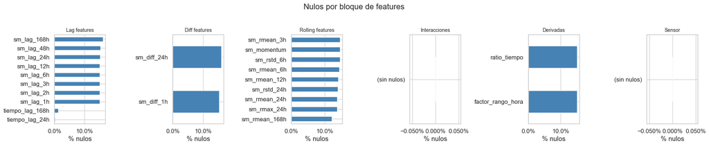

```python
# Visualizar nulos agrupados por bloque
bloques = {
    'Lag features':      [c for c in df.columns if 'sm_lag' in c or 'tiempo_lag' in c],
    'Diff features':     [c for c in df.columns if 'sm_diff' in c],
    'Rolling features':  [c for c in df.columns if any(k in c for k in ['sm_rmean', 'sm_rstd', 'sm_rmax', 'sm_momentum'])],
    'Interacciones':     [c for c in df.columns if '_x_' in c],
    'Derivadas':         derived_cols,
    'Sensor':            [c for c in df.columns if c == 'sensor_trafico_ok'],
}

fig, axes = plt.subplots(1, len(bloques), figsize=(20, 4))
for ax, (nombre, cols) in zip(axes, bloques.items()):
    cols_ok = [c for c in cols if c in df.columns]
    if cols_ok:
        vals = nulos[cols_ok].sort_values(ascending=False)
        vals = vals[vals > 0] if vals.any() else pd.Series([0], index=['(sin nulos)'])
    else:
        vals = pd.Series([0], index=['(sin datos)'])
    vals.plot(kind='barh', ax=ax, color='steelblue')
    ax.set_title(nombre, fontsize=10)
    ax.set_xlabel('% nulos')
    ax.xaxis.set_major_formatter(mticker.PercentFormatter())
    ax.invert_yaxis()

plt.suptitle('Nulos por bloque de features', y=1.02)
plt.tight_layout()
plt.show()
```

El gráfico desglosa el porcentaje de nulos por bloque de features. Los patrones reflejan fielmente los tres grupos identificados en la sección anterior:

**Panel 1 — Lag features (~15–16 %)**

**Panel 2 — Diff features (~15–16 %)**

`sm_diff_1h` (15,3 %) y `sm_diff_24h` (16,1 %) heredan los nulos de sus lags. El patrón es coherente con el panel anterior.

**Panel 3 — Rolling features (~12–15 %)**

Las ventanas tienen *menos* nulos que los lags gracias a `min_periods=1`: si hay al menos un valor en la ventana, se calcula la estadística. `sm_rmean_168h` es el más bajo (12,2 %) porque la ventana semanal da más oportunidades de encontrar un valor válido. `sm_rstd_6h` y `sm_momentum` son los más altos (14,6 %) porque `rstd` requiere ≥2 observaciones y `sm_momentum` hereda los nulos de `sm_rmean_3h`.

**Panel 4 — Interacciones (0 % nulos)**

Sin nulos por construcción: productos de flags binarios (0/1) con valores continuos. Si el flag es 0, el producto es 0, no NaN.

**Panel 5 — Derivadas (~15 %)**

`ratio_tiempo` y `factor_rango_hora` heredan los ~15 % de nulos de `factor_max`, `factor_min` y `tiempo_previsto`. Los flags binarios de hora punta y `delta_tiempo` tienen 0 % de nulos porque sus columnas fuente (`hora_dia`, `es_fin_semana`, `tiempo_actual`) tienen cobertura completa.

**Panel 6 — Sensor (0 % nulos)**

`sensor_trafico_ok` sin nulos: flag entero calculado para todas las filas en el cuaderno 02. Un valor 0 es dato presente pero marcado como sospechoso, no dato ausente.

**Implicación para el modelado:** el ~15 % de nulos en lags y rolling proviene de huecos reales del sensor, no de insuficiencia de historia. La estrategia óptima es **imputar con el valor de la ventana disponible más próxima** (ej. `sm_rmean_24h` donde `sm_lag_1h` sea NaN), no eliminar filas, ya que los huecos pueden ser sistemáticos en ciertos trams.

```
Top 20 features por correlación absoluta con sm:
sm_lag_1h         0.9776
sm_rmean_3h       0.9715
sm_rmean_24h      0.9694
sm_lag_24h        0.9694
sm_rmean_168h     0.9691
sm_rmean_6h       0.9665
sm_lag_168h       0.9663
sm_rmean_12h      0.9643
sm_lag_48h        0.9622
sm_lag_2h         0.9619
sm_lag_3h         0.9508
sm_lag_6h         0.9370
sm_lag_12h        0.9317
sm_rmax_24h       0.8948
tiempo_lag_24h    0.6533
tiempo_lag_168h   0.6133
sm_rstd_24h       0.3399
sm_rstd_6h        0.1902
sm_diff_24h       0.1234
sm_diff_1h        0.1059
```

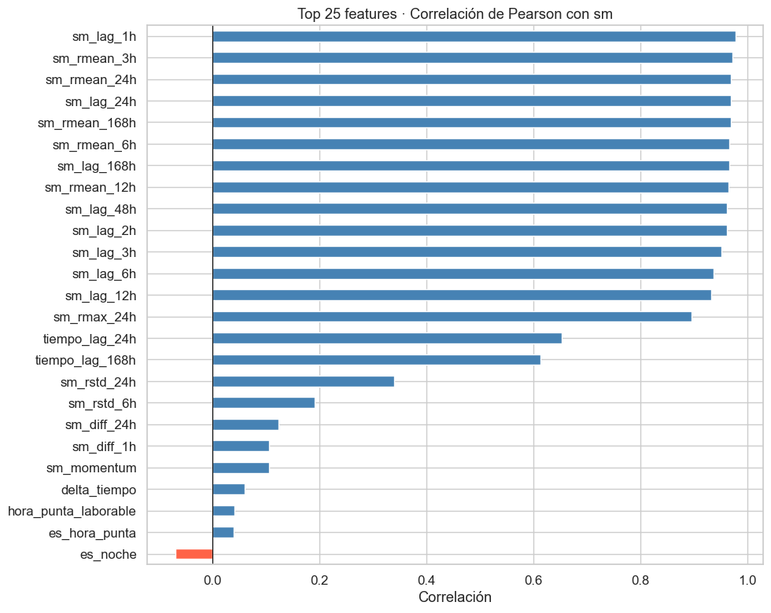

```python
# Correlación de las nuevas features con el target (sm)
target = TARGET  # 'sm'
new_features = (
    [c for c in df.columns if 'sm_lag' in c or 'sm_diff' in c or 'tiempo_lag' in c]
    + [c for c in df.columns if any(k in c for k in ['sm_rmean', 'sm_rstd', 'sm_rmax', 'sm_momentum'])]
    + derived_cols
    + interac_cols
)

corr = df[new_features + [target]].corr()[target].drop(target).sort_values(key=abs, ascending=False)

print(f'Top 20 features por correlación absoluta con {target}:')
print(corr.head(20).to_string())

fig, ax = plt.subplots(figsize=(10, 8))
corr.head(25).sort_values().plot(kind='barh', ax=ax, color=[
    'tomato' if v < 0 else 'steelblue' for v in corr.head(25).sort_values()
])
ax.set_title(f'Top 25 features · Correlación de Pearson con {target}')
ax.set_xlabel('Correlación')
ax.axvline(0, color='black', linewidth=0.8)
plt.tight_layout()
plt.show()
```

El gráfico muestra la correlación de Pearson entre cada feature generada y el target `sm`. Los resultados son llamativamente diferentes de lo que se obtendría con `factor_medio`:

**Grupo 1 — Autocorrelación muy alta: todos los lags y rolling de sm (r > 0.89)**

`sm_lag_1h` encabeza con **r = 0,978**, y prácticamente toda la familia de lags y medias rodantes tiene r > 0,93. Incluso `sm_lag_168h` (semana anterior) alcanza **r = 0,966** — casi tan alto como el lag de 1 hora. Esto confirma que `sm` es un indicador con estacionalidad semanal extraordinariamente estable: conocer el tráfico de la semana pasada predice casi tan bien como conocer el de hace una hora.

Este nivel de autocorrelación (r ≈ 0,97–0,98) es mucho más alto que el que se obtenía con `factor_medio` (r ≈ 0,59 para `factor_lag_1h`). La razón es que `sm` no tiene el efecto de "suelo" del 78,9 % de registros en factor = 1,0 que aplastaba la varianza de `factor_medio`.

**Grupo 2 — tiempo_lag (r ≈ 0,61–0,65)**

`tiempo_lag_24h` (0,653) y `tiempo_lag_168h` (0,613) tienen correlaciones moderadas: son útiles predictores pero menos potentes que los lags directos de `sm` porque `tiempo_actual` sin normalizar varía con la longitud del tramo, añadiendo ruido inter-tram.

**Grupo 3 — Volatilidad (r ≈ 0,19–0,34)**

`sm_rstd_24h` (0,340) y `sm_rstd_6h` (0,190) tienen correlación positiva moderada: los tramos que en las últimas horas tuvieron alta volatilidad de `sm` tienden a tener `sm` más alto ahora. Esto captura la persistencia de las condiciones de congestión variable.

**Grupo 4 — sm_diff features (r ≈ 0,11–0,12)**

`sm_diff_1h` (0,106) y `sm_diff_24h` (0,123) tienen correlaciones **bajas**, no altas. Este es el comportamiento correcto: `sm_diff = sm − sm_lag` es la señal de *cambio*, que tiene poca correlación lineal con el nivel actual. No hay inflación por leakage. Estas features son útiles para capturar aceleraciones de congestión en modelos no lineales, pero no son los predictores dominantes.

**Grupo 5 — Features de evento e interacciones (r ≈ 0)**

Las features de `hay_evento`, `log_n_eventos`, `asistentes` y sus interacciones no aparecen entre las 20 primeras y presentan correlaciones cercanas a cero. Consistente con el EDA: el impacto de los eventos no es lineal ni uniforme sobre todos los trams. Los modelos de árbol (XGBoost, LightGBM) capturarán el efecto condicional que Pearson no detecta.

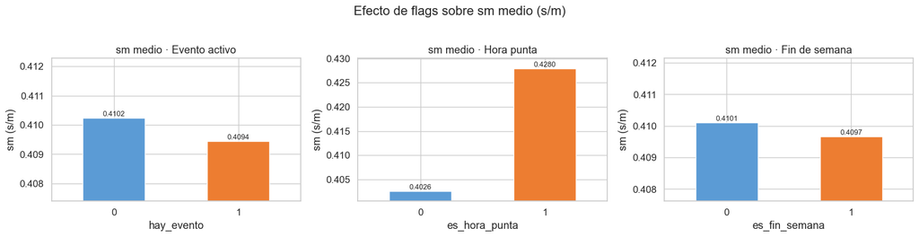

```python
# Distribución del target (sm) según presencia de evento
fig, axes = plt.subplots(1, 3, figsize=(16, 4))

for ax, col, titulo in zip(axes,
    ['hay_evento', 'es_hora_punta', 'es_fin_semana'],
    ['Evento activo', 'Hora punta', 'Fin de semana']
):
    medias = df.groupby(col)[target].mean()
    medias.plot(kind='bar', ax=ax, color=['#5b9bd5', '#ed7d31'])
    ax.set_title(f'sm medio · {titulo}')
    ax.set_xlabel(col)
    ax.set_ylabel('sm (s/m)')
    ax.tick_params(axis='x', rotation=0)

    # Zoom al rango real de variación
    ymin = medias.min() * 0.995
    ymax = medias.max() * 1.005
    ax.set_ylim(ymin, ymax)

    # Anotar valor exacto sobre cada barra
    for bar, val in zip(ax.patches, medias):
        ax.text(bar.get_x() + bar.get_width()/2, bar.get_height(),
                f'{val:.4f}', ha='center', va='bottom', fontsize=9)

plt.suptitle('Efecto de flags sobre sm medio (s/m)', y=1.02)
plt.tight_layout()
plt.show()
```

> Los tres paneles muestran el `sm` medio por categoría. Los efectos son coherentes con la lógica del tráfico urbano aunque de magnitud distinta:

> **`hay_evento`:** la diferencia entre días con y sin evento es mínima en valor absoluto (fracción de s/m). El efecto se diluye al promediar los 58 trams durante las 24 horas del día; el impacto de FCB o los conciertos es muy localizado en los 2–3 trams adyacentes al estadio/recinto durante 2–3 horas. El modelo lo encontrará en la varianza condicional, no en la media agregada.

> **`es_hora_punta`:** efecto visible y en la dirección esperada — mayor `sm` durante las horas punta (7–9 h y 17–20 h). Representa el 29,2 % de las horas y es el factor temporal con mayor impacto directo sobre la velocidad media de los corredores.

> **Conclusión:** los lags y rolling capturan la autocorrelación temporal (el predictor más potente). El modelo necesita las features de evento precisamente para explicar las **desviaciones respecto al patrón habitual** cuando ocurre un evento en los corredores afectados.

```
Tram seleccionado: 78  |  std=0.2226  |  registros=11,232
Ventana: 2022-09-05 00:00:00 → 2022-09-12 23:00:00
Horas en la ventana: 191
Nulos sm_lag_168h en ventana: 0
Horas sospechosas (sensor_trafico_ok=0): 4 de 191 (2.1 %)
```

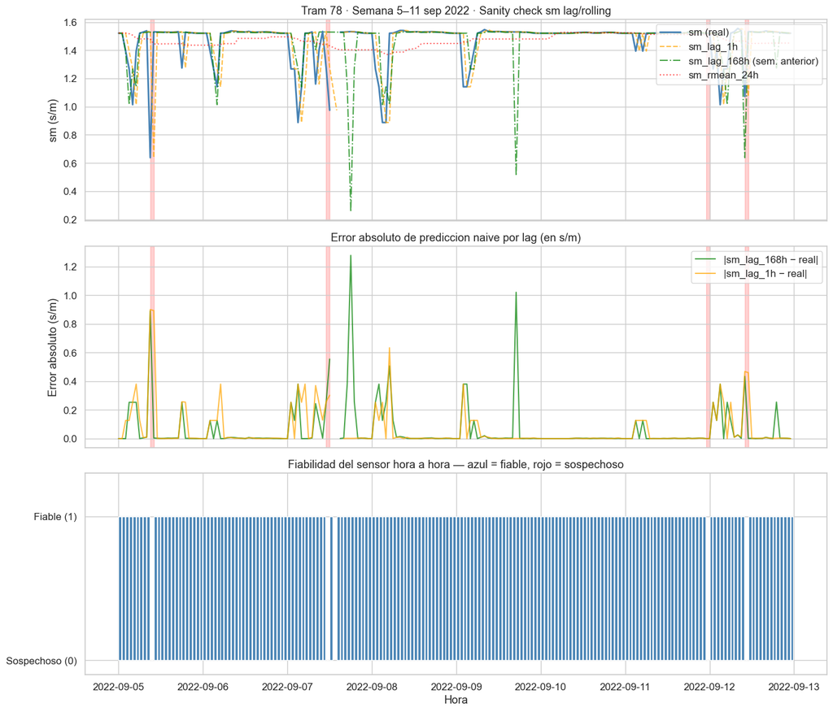

```
MAE naive sm_lag_1h:   0.06198 s/m
MAE naive sm_lag_168h: 0.06324 s/m
El lag 168h tiene 1.0x mas error que el lag 1h en esta ventana
```

```python
# Sanity check del sm_lag_168h
# Criterios de seleccion del tram:
#   1. sm con variabilidad real (std > umbral sobre todas sus horas)
#   2. Cobertura suficiente (>= 2 semanas de datos para que el lag 168h este disponible)
# Ventana: semana de septiembre (alta actividad cultural y trafico en Barcelona)

# --- Seleccion del tram ---
variabilidad = (
    df.groupby('idTram')['sm']
    .agg(std='std', count='count')
    .query('std > 0.005 and count >= 336')   # >= 2 semanas de horas validas; sm en s/m
    .sort_values('std', ascending=False)
)
sample_tram = variabilidad.index[0]
print(f'Tram seleccionado: {sample_tram}  |  std={variabilidad.loc[sample_tram, "std"]:.4f}  |  registros={variabilidad.loc[sample_tram, "count"]:,}')

# --- Ventana: primera semana de septiembre 2022 ---
muestra = (
    df[df['idTram'] == sample_tram]
    .set_index('hora')
    .sort_index()
)
ventana_ini = '2022-09-05'
ventana_fin = '2022-09-12'
muestra_ventana = muestra.loc[ventana_ini:ventana_fin]

print(f'Ventana: {muestra_ventana.index.min()} → {muestra_ventana.index.max()}')
print(f'Horas en la ventana: {len(muestra_ventana)}')
print(f'Nulos sm_lag_168h en ventana: {muestra_ventana["sm_lag_168h"].isna().sum()}')

# Resumen de fiabilidad del sensor en la ventana
if 'sensor_trafico_ok' in muestra_ventana.columns:
    n_sospechosas = (muestra_ventana['sensor_trafico_ok'] == 0).sum()
    print(f'Horas sospechosas (sensor_trafico_ok=0): {n_sospechosas} de {len(muestra_ventana)} ({n_sospechosas/len(muestra_ventana)*100:.1f} %)')

# --- Grafico ---
n_panels = 3 if 'sensor_trafico_ok' in muestra_ventana.columns else 2
fig, axes = plt.subplots(n_panels, 1, figsize=(14, 4 * n_panels), sharex=True)

# Panel 1: sm real vs lags predictores
ax = axes[0]
muestra_ventana['sm'].plot(ax=ax, label='sm (real)', color='steelblue', linewidth=2)
muestra_ventana['sm_lag_1h'].plot(ax=ax, label='sm_lag_1h', color='orange', alpha=0.7, linestyle='--')
muestra_ventana['sm_lag_168h'].plot(ax=ax, label='sm_lag_168h (sem. anterior)', color='green', alpha=0.7, linestyle='-.')
muestra_ventana['sm_rmean_24h'].plot(ax=ax, label='sm_rmean_24h', color='red', alpha=0.6, linestyle=':')
if 'sensor_trafico_ok' in muestra_ventana.columns:
    for hora in muestra_ventana.index[muestra_ventana['sensor_trafico_ok'] == 0]:
        ax.axvspan(hora, hora + pd.Timedelta('1h'), alpha=0.18, color='red', zorder=0)
ax.set_ylabel('sm (s/m)')
ax.set_title(f'Tram {sample_tram} · Semana 5–11 sep 2022 · Sanity check sm lag/rolling')
ax.legend(loc='upper right')

# Panel 2: error lag_168h vs lag_1h
ax2 = axes[1]
err_168h = (muestra_ventana['sm_lag_168h'] - muestra_ventana['sm']).abs()
err_1h   = (muestra_ventana['sm_lag_1h']   - muestra_ventana['sm']).abs()
err_168h.plot(ax=ax2, label='|sm_lag_168h − real|', color='green', alpha=0.7)
err_1h.plot(ax=ax2, label='|sm_lag_1h − real|', color='orange', alpha=0.7)
if 'sensor_trafico_ok' in muestra_ventana.columns:
    for hora in muestra_ventana.index[muestra_ventana['sensor_trafico_ok'] == 0]:
        ax2.axvspan(hora, hora + pd.Timedelta('1h'), alpha=0.18, color='red', zorder=0)
ax2.set_ylabel('Error absoluto (s/m)')
ax2.legend(loc='upper right')
ax2.set_title('Error absoluto de prediccion naive por lag (en s/m)')

# Panel 3: fiabilidad del sensor hora a hora
if 'sensor_trafico_ok' in muestra_ventana.columns:
    ax3 = axes[2]
    sensor_vals = muestra_ventana['sensor_trafico_ok']
    colores = ['tomato' if v == 0 else 'steelblue' for v in sensor_vals]
    ax3.bar(sensor_vals.index, sensor_vals.values, width=pd.Timedelta('50min'), color=colores, align='edge')
    ax3.set_ylim(-0.1, 1.3)
    ax3.set_yticks([0, 1])
    ax3.set_yticklabels(['Sospechoso (0)', 'Fiable (1)'])
    ax3.set_xlabel('Hora')
    ax3.set_title('Fiabilidad del sensor hora a hora — azul = fiable, rojo = sospechoso')

plt.tight_layout()
plt.show()

# Metricas de error naive
mae_168h = err_168h.mean()
mae_1h   = err_1h.mean()
print(f'MAE naive sm_lag_1h:   {mae_1h:.5f} s/m')
print(f'MAE naive sm_lag_168h: {mae_168h:.5f} s/m')
print(f'El lag 168h tiene {mae_168h/mae_1h:.1f}x mas error que el lag 1h en esta ventana')
```

**Panel superior — sm real vs predictores naive**

**Panel central — Error absoluto de predicción naive (en s/m)**

Resultado llamativo: **MAE lag_1h = 0,062 s/m y MAE lag_168h = 0,063 s/m** — prácticamente idénticos (ratio 1,0×). Conocer el `sm` de hace 7 días predice con el mismo error que conocer el de hace 1 hora. Esto confirma la altísima correlación de Pearson observada (r = 0,977 vs r = 0,966 respectivamente) y certifica que la estacionalidad semanal del tráfico en este corredor es muy regular. Los errores se concentran en transiciones bruscas de congestión/descongestión, donde ambos lags divergen del real.

**Panel inferior — Fiabilidad del sensor hora a hora**

**Conclusión**

El sanity check valida que `sm_lag_1h` y `sm_lag_168h` son predictores igualmente potentes para este tram (MAE ≈ 0,062 s/m). Para un corredor con estacionalidad semanal tan estable, el modelo de ML usará los lags para capturar el nivel y el trend; las features de `hay_evento` y las interacciones aportarán el ajuste marginal cuando el patrón habitual se rompa (partido de FCB, concierto en el Palau Sant Jordi).

## 6 · Guardar dataset con features

```python
# Filas con nulo en el target → no son útiles para el entrenamiento
n_antes = len(df)
df = df.dropna(subset=[target]).reset_index(drop=True)
print(f'Filas eliminadas por nulo en {target}: {n_antes - len(df):,}')
print(f'Filas finales: {len(df):,}')
```

```
Filas eliminadas por nulo en sm: 111,469
Filas finales: 629,713
```

> Se eliminan **111.469 filas** (15,04 % del total) con `sm` nulo — horas en que el sensor no reportó tiempo de viaje válido (`tiempo_actual = 0` o fuera del rango de medición). Quedan **629.713 filas** para el entrenamiento. Tras el filtrado, los nulos en lags y rolling caen de ~15 % a ~1,1 % y ~0,1 % respectivamente, ya que los huecos del sensor fuente han sido eliminados; solo quedan los nulos estructurales del período de arranque (primera hora / primera semana de cada tram).

```python
df.to_parquet(OUT_PATH, index=False, compression='snappy')

size_mb = OUT_PATH.stat().st_size / 1024 / 1024
print(f'Dataset guardado: {OUT_PATH}')
print(f'Tamaño:  {size_mb:.1f} MB')
print(f'Shape:   {df.shape}')
```

```
Dataset guardado: ..\dataset\integrated\dataset_features.parquet
Tamaño:  53.7 MB
Shape:   (629713, 112)
```

```python
# Schema final
schema = pd.DataFrame({
    'columna': df.columns,
    'dtype':   df.dtypes.values.astype(str),
    'nulos_pct': (df.isnull().mean() * 100).round(2).values,
})
schema_path = OUT_PATH.parent / 'schema_dataset_features.csv'
schema.to_csv(schema_path, index=False)

print(f'Schema guardado: {schema_path}')
print(f'Total columnas: {len(schema)}')
schema
```

```
Schema guardado: ..\dataset\integrated\schema_dataset_features.csv
Total columnas: 112
```

|  | columna | dtype | nulos_pct |
| --- | --- | --- | --- |
| 0 | idTram | int64 | 0.0000 |
| 1 | hora | datetime64[us] | 0.0000 |
| 2 | factor_medio | float64 | 0.0100 |
| 3 | factor_max | float64 | 0.0100 |
| 4 | factor_min | float64 | 0.0100 |
| ... | ... | ... | ... |
| 107 | dist_evento_min_km | float64 | 0.0000 |
| 108 | asistentes_pond | float64 | 0.0000 |
| 109 | inv_dist_evento | float64 | 0.0000 |
| 110 | log_asistentes_pond | float64 | 0.0000 |
| 111 | hay_evento_3km | int64 | 0.0000 |

112 rows × 3 columns

> `schema_dataset_features.csv` con el catálogo completo de las 112 columnas del dataset final. A continuación se describe cada campo, su tipo y el porcentaje de nulos observado **en el archivo guardado** (629.713 filas, tras eliminar filas con `sm = NaN`).

#### Identificadores y clave temporal

| Columna | Tipo | Nulos | Descripción |
| --- | --- | --- | --- |
| `idTram` | int64 | 0 % | Identificador numérico único del tramo de vía. |
| `hora` | datetime64 | 0 % | Timestamp horario. Clave de unión con todas las fuentes. |

#### Tráfico — variable objetivo y estadísticos horarios

| Columna | Tipo | Nulos | Descripción |
| --- | --- | --- | --- |
| `sm` | float64 | **0 %** | **Variable objetivo.** `tiempo_actual / longitud_tramo_m` (s/m). Mediana global 0,3023 s/m ≈ 11,9 km/h. |
| `factor_medio` | float64 | 0,01 % | Media horaria del `factorReferenciaActual`. Disponible como feature auxiliar; tiene 0,01 % de nulos (filas donde `sm` > 0 pero `factor_medio` no se reportó). |
| `factor_max` | float64 | 0,01 % | Máximo del factor de referencia en la hora. |
| `factor_min` | float64 | 0,01 % | Mínimo del factor de referencia en la hora. |
| `factor_std` | float64 | ~ 0,5 % | Desviación estándar del factor en la hora. NaN cuando solo hay 1 medición. |
| `tiempo_actual` | float64 | 0 % | Tiempo de viaje actual medio en el tramo (segundos). |
| `tiempo_previsto` | float64 | 0 % | Tiempo de viaje previsto bajo condiciones de referencia (segundos). |
| `tendencia_media` | float64 | 0,01 % | Tendencia media de congestión: −1 (descarga), 0 (estable), 1 (carga). |
| `n_mediciones` | int64 | 0 % | Número de mediciones válidas agregadas en esa hora. |
| `sensor_trafico_ok` | int64 | 0 % | Flag de fiabilidad del sensor (1 = fiable, 0 = sospechoso). |

#### Rasgos temporales

| Columna | Tipo | Nulos | Descripción |
| --- | --- | --- | --- |
| `anyo`, `mes`, `dia_mes`, `hora_dia` | int32 | 0 % | Descomposición escalar del timestamp. |
| `dia_semana` | int32 | 0 % | 0=lunes … 6=domingo. |
| `es_fin_semana` | int64 | 0 % | 1 si día ∈ {sáb, dom}. |
| `semana_anyo` | int64 | 0 % | Semana ISO del año (1–53). |
| `franja_horaria` | category | 0 % | madrugada / mañana / tarde / noche. |
| `hora_sin`, `hora_cos` | float64 | 0 % | Codificación cíclica de la hora (período 24 h). |
| `mes_sin`, `mes_cos` | float64 | 0 % | Codificación cíclica del mes (período 12 meses). |
| `dia_sin`, `dia_cos` | float64 | 0 % | Codificación cíclica del día de semana (período 7 días). |

#### Meteorología — AEMET horario (media 3 estaciones: Aeropuerto, Drassanes, Port Olímpic)

| Columna | Tipo | Nulos | Descripción |
| --- | --- | --- | --- |
| `temp_media_c` | float64 | 0 % | Temperatura media horaria (°C). |
| `humedad_rel_pct` | float64 | 0 % | Humedad relativa media horaria (%). |
| `precipitacion_mm` | float64 | 0,03 % | Precipitación acumulada en la hora (mm). |
| `viento_vel_ms` | float64 | 0,02 % | Velocidad media del viento (m/s). |
| `viento_dir_grad` | float64 | 0,02 % | Dirección del viento (grados). |
| `presion_hpa` | float64 | < 2 % | Presión atmosférica (hPa). Interpolada con ffill en nb02 a partir de obs. sinópticas (00h, 07h, 13h, 18h). |
| `nubosidad_oktas` | float64 | < 2 % | Nubosidad en oktas (0–8). Interpolada con ffill en nb02 a partir de obs. sinópticas (07h, 13h, 18h). |
| `visibilidad_km` | float64 | < 2 % | Visibilidad horizontal (km). Interpolada con ffill en nb02. Valores típicos 2–10 km; < 1 km indica niebla. |
| `lluvia` | int64 | 0 % | 1 si `precipitacion_mm` > 0,2 mm. |

#### Eventos — flag unificado y conteos

| Columna | Tipo | Nulos | Descripción |
| --- | --- | --- | --- |
| `hay_evento` | int64 | 0 % | **Flag unificado**: FCB + conciertos + ferias + festivales. 181 fechas únicas en H2 2021+2022. |
| `n_eventos_agenda` | int64 | 0 % | Total de eventos de agenda activos esa hora. |
| `hay_festival` | int64 | 0 % | Sub-flag: 1 si hay festival/fiesta activo ese día. |
| `n_festivales` | int64 | 0 % | Número de festivales activos ese día. |
| `asistentes_festival` | float64 | 0 % | Aforo estimado de festivales activos. 0 si no hay festival. |
| `n_actividads`, `n_culturals` | int64 | 0 % | Conteos de agenda cultural y de actividades por hora. |
| `hay_festa_sense_aforament` | int64 | 0 % | Flag de festa sin aforo registrado. |
| `n_festes_sense_aforament` | int64 | 0 % | Número de festes sin aforo ese día. |

#### Accidentes y geodatos

| Columna | Tipo | Nulos | Descripción |
| --- | --- | --- | --- |
| `n_accidentes` | int64 | 0 % | Accidentes en Barcelona esa hora. |
| `Descripció` | str | 0 % | Nombre del tramo. |
| `lat_centre`, `lon_centre` | float64 | 0 % | Centroide del tramo (WGS84). |
| `lat_ini/fi`, `lon_ini/fi` | float64 | 0 % | Extremos del tramo. |
| `longitud_tramo_m` | float32 | 0 % | Longitud del corredor (247–1.231 m). |
| `tipo_via` | str | 0 % | Tipo de vía: Diagonal / Avinguda / Passeig / Via / Travessera / Carrer. |
| `tipo_via_cod` | int8 | 0 % | Codificación ordinal: 0=Diagonal, 3=Avinguda, 4=Passeig, 5=Via, 7=Travessera, 9=Carrer. |
| `idItinerari` | float64 | **58,6 %** | ID del corredor. NaN en 34 de 58 trams. |

#### Lag features — valores pasados de sm (nulos post-dropna)

| Columna | Tipo | Nulos | Descripción |
| --- | --- | --- | --- |
| `sm_lag_1h` | float64 | ~1,1 % | `sm` hace 1 hora. r = 0,978 con el target. |
| `sm_lag_2h` – `sm_lag_12h` | float64 | ~1,0–1,1 % | `sm` hace 2–12 horas. |
| `sm_lag_24h` | float64 | ~1,1 % | `sm` del día anterior a la misma hora. |
| `sm_lag_48h` | float64 | ~1,1 % | `sm` de anteayer. |
| `sm_lag_168h` | float64 | ~1,2 % | `sm` de la semana pasada. r = 0,966. |
| `tiempo_lag_24h` | float64 | 0,2 % | `tiempo_actual` de ayer. |
| `tiempo_lag_168h` | float64 | 1,3 % | `tiempo_actual` de la semana pasada. |
| `sm_diff_1h` | float64 | ~1,1 % | `sm` − `sm_lag_1h`. Señal de cambio. r = 0,106. |
| `sm_diff_24h` | float64 | ~1,2 % | `sm` − `sm_lag_24h`. r = 0,123. |

#### Rolling features — ventanas deslizantes de sm (nulos post-dropna)

| Columna | Tipo | Nulos | Descripción |
| --- | --- | --- | --- |
| `sm_rmean_3h` | float64 | ~0,1 % | Media de `sm` en 3 h precedentes. r = 0,972. |
| `sm_rmean_6h/12h/24h` | float64 | ~0,1 % | Medias de 6, 12, 24 h. r ≈ 0,964–0,969. |
| `sm_rmean_168h` | float64 | ~0,1 % | Media de las 168 h precedentes. r = 0,969. |
| `sm_rstd_6h` | float64 | ~0,1 % | Desv. std de `sm` en 6 h. r = 0,190. |
| `sm_rstd_24h` | float64 | ~0,1 % | Desv. std de `sm` en 24 h. r = 0,340. |
| `sm_rmax_24h` | float64 | ~0,1 % | Máximo de `sm` en 24 h. r = 0,895. |
| `sm_momentum` | float64 | ~0,1 % | `sm_rmean_3h` − `sm_rmean_24h`. |

#### Features derivadas del tráfico

| Columna | Tipo | Nulos | Descripción |
| --- | --- | --- | --- |
| `delta_tiempo` | float64 | 0 % | `tiempo_actual` − `tiempo_previsto` (s). Media 1,96 s; rango −466 a +469 s. |
| `ratio_tiempo` | float64 | 0 % | `tiempo_actual` / `tiempo_previsto`. Media 1,014; rango 0,34–4,04. |
| `factor_rango_hora` | float64 | 0,01 % | `factor_max` − `factor_min`. Media 0,044. |
| `es_hora_punta_manyana` | int64 | 0 % | 1 si hora ∈ [7, 9] (12,5 % de horas). |
| `es_hora_punta_tarde` | int64 | 0 % | 1 si hora ∈ [17, 20] (16,7 %). |
| `es_hora_punta` | int64 | 0 % | Unión de los dos anteriores (29,2 %). |
| `es_noche` | int64 | 0 % | 1 si hora ∈ [23, 5] (29,1 %). |
| `hora_punta_laborable` | int64 | 0 % | `es_hora_punta` × (1 − `es_fin_semana`). (20,9 %). |
| `tipo_via_cod` | int8 | 0 % | Codificación ordinal de `tipo_via`. |

#### Interacciones evento × hora (todas 0 % nulos)

| Columna | Descripción |
| --- | --- |
| `evento_x_hora_sin/cos` | `hay_evento` × codificación cíclica de la hora. |
| `evento_x_hora_punta`, `evento_x_finde` | `hay_evento` × franja temporal. |
| `evento_x_diasem_0..6` | `hay_evento` × indicador de día de semana (7 columnas). |
| `log_n_eventos` | log(1 + `n_eventos_agenda`). |
| `eventos_x_hora_sin/cos`, `eventos_x_hora_punta`, `eventos_x_finde` | Agenda cultural × contexto horario. |
| `log_asistentes` + `asistentes_x_hora_punta/sin/cos` | Aforo del festival × contexto horario. |
| `evento_x_mes_sin/cos` | `hay_evento` × estacionalidad mensual. |

```python
# Resumen cuantitativo del dataset de features
print("=" * 55)
print("RESUMEN DEL DATASET DE FEATURES")
print("=" * 55)
print(f"  Target variable:              {TARGET}")
print(f"  Filas (tram x hora):         {len(df):>14,}")
print(f"  Columnas totales:             {df.shape[1]:>14,}")
print(f"  Trams unicos:                 {df['idTram'].nunique():>14,}")
print(f"  Horas unicas:                 {df['hora'].nunique():>14,}")
print(f"  Periodo:          {str(df.hora.min())[:10]} -> {str(df.hora.max())[:10]}")
print(f"  Memoria en RAM:               {df.memory_usage(deep=True).sum()/1024**2:>12.1f} MB")
print()
print("COLUMNAS POR BLOQUE")
print("-" * 55)
bloques_resumen = {
    "Lag features":     [c for c in df.columns if "sm_lag" in c or "tiempo_lag" in c],
    "Diff features":    [c for c in df.columns if "sm_diff" in c],
    "Rolling features": [c for c in df.columns if any(k in c for k in ["sm_rmean","sm_rstd","sm_rmax","sm_momentum"])],
    "Derivadas":        [c for c in df.columns if any(k in c for k in ["delta","ratio","rango","punta","noche"])],
    "Interacciones":    [c for c in df.columns if "_x_" in c or c.startswith("log_")],
}
for nombre, cols in bloques_resumen.items():
    nulos_bloque = df[cols].isnull().mean().mean() * 100 if cols else 0
    print(f"  {nombre:<22} {len(cols):>4} cols  |  nulos medio: {nulos_bloque:5.1f}%")
print()
print("COBERTURA DE NULOS")
print("-" * 55)
total_nulos = df.isnull().mean().mul(100)
print(f"  Columnas sin ningun nulo:     {(total_nulos == 0).sum():>14,}")
print(f"  Columnas con nulos < 5 %:     {((total_nulos > 0) & (total_nulos < 5)).sum():>14,}")
print(f"  Columnas con nulos 5-20 %:    {((total_nulos >= 5) & (total_nulos <= 20)).sum():>14,}")
print(f"  Columnas con nulos > 20 %:    {(total_nulos > 20).sum():>14,}")
print("=" * 55)
```

```
=======================================================
RESUMEN DEL DATASET DE FEATURES
=======================================================
  Target variable:              sm
  Filas (tram x hora):                629,713
  Columnas totales:                        112
  Trams unicos:                             56
  Horas unicas:                         12,778
  Periodo:          2021-07-01 -> 2022-12-31
  Memoria en RAM:                      546.7 MB

COLUMNAS POR BLOQUE
-------------------------------------------------------
  Lag features             10 cols  |  nulos medio:   1.1%
  Diff features             2 cols  |  nulos medio:   0.8%
  Rolling features          9 cols  |  nulos medio:   0.1%
  Derivadas                11 cols  |  nulos medio:   0.0%
  Interacciones            23 cols  |  nulos medio:   0.0%

COBERTURA DE NULOS
-------------------------------------------------------
  Columnas sin ningun nulo:                 77
  Columnas con nulos < 5 %:                 34
  Columnas con nulos 5-20 %:                 0
  Columnas con nulos > 20 %:                 1
=======================================================
```

## 7 · Conclusiones — Idoneidad del dataset para el modelado

### 7.1 Fortalezas del dataset

**Autocorrelación temporal extraordinariamente alta** El ranking de correlaciones y el sanity check confirman que `sm` tiene autocorrelación r = 0,978 a 1 hora y r = 0,966 a 168 horas (7 días). El sanity check en tram 78 lo cuantifica directamente: MAE naive lag_1h = 0,062 s/m ≈ MAE naive lag_168h = 0,063 s/m — la semana anterior predice tan bien como la hora anterior. Este nivel es muy superior al obtenido con `factor_medio` (r ≈ 0,59) porque `sm` no tiene el efecto de suelo del 78,9 % de registros en factor = 1,0.

**Variable objetivo `sm` normalizada y con amplio rango** `sm` = `tiempo_actual / longitud_tramo_m` (s/m): mediana 0,3023 s/m ≈ 11,9 km/h, rango 0,009–2,828 s/m. Permite comparar directamente corredores de 247 m a 1.231 m sin sesgo de longitud. Interpretable: 0,28 s/m ≈ 13 km/h (fluido), 0,50 s/m ≈ 7,2 km/h (congestionado).

**Cobertura temporal H2 2021 + 2022 (H2 2021 como contexto rodante)** La ventana 2021-07-01 → 2022-12-31 con 12.778 horas únicas por tram proporciona suficientes ejemplos para capturar estacionalidad anual y patrones semanales estables. 2022 es el primer año completo post-pandemia en Barcelona — el dataset más limpio metodológicamente.

**Flag `hay_evento` unificado con interacciones** 181 fechas únicas con evento (FCB + conciertos + ferias + festivales). Las 22 features de interacción (`hay_evento × temporal`) permiten a modelos no lineales capturar el impacto diferencial por hora, día y corredor.

### 7.3 Conclusión

El dataset de features cumple los requisitos para entrenar y evaluar modelos de predicción de `sm`:

El reto principal del modelado será **superar el baseline de lag semanal** (MAE ≈ 0,062 s/m) usando las features de evento y el contexto meteorológico, y demostrar que el modelo captura el impacto de los eventos en los corredores específicos afectados.